# Decision Analysis for Laser Leveling Application

Creating a decision support model for small-scale farmers in Vietnam using the decisionSupport R package by Lüdeling et al.

Arnaud, Barbacias, Bigerna, Florido, Schönbach

2023-07-14

# Introduction

Water scarcity and the efficient management of water resources have emerged as major challenges in agricultural development worldwide. With the increasing impacts of climate change, ensuring sustainable food production has become a pressing concern. Irrigated rice cultivation plays a vital role in ensuring global food security, providing a substantial portion of the world’s population with a staple crop (Bouman et al. 2007). Rice is a primary dietary staple for billions of people, particularly in Asia, where it serves as a crucial source of calories and nutrition (Seck et al. 2012). Rice consumption has increased globally over the last decade. Statista data shows that in the cropping year 2020/2021, the world population consumed about 504.3 million metric tons of rice, increasing from 437.18 million metric tons in 2008/2009 (Cuaton and Delina 2022). To meet the growing demand for rice and ensure stable food supplies, efficient water management is essential. However, irrigated rice farming requires significant water resources, accounting for a substantial portion of global freshwater consumption Yang, Zehnder, and Hoekstra (2006). As water scarcity becomes an increasing concern, optimizing water use in irrigated rice fields is crucial (Molden et al. 2010)**.**

Irrigated rice fields play a crucial role in Vietnam’s agricultural landscape, providing sustenance for its population and contributing significantly to the national economy (Ngoc, Keenan, and Herbohn 2012). However, traditional manual leveling methods used in rice cultivation are time-consuming, labor-intensive, and often result in uneven water distribution, leading to sub-optimal crop growth and reduced yield (Tuan, Linh, and Nhan 2014). To address these challenges, laser leveling techniques have emerged as a promising solution for irrigated rice fields. Here we enumerate some of the benefits of laser leveling, its potential impact on agricultural productivity, and its suitability for the Vietnamese context.

1. Improved Water Management: Laser leveling technology ensures precise land grading, creating a uniform surface with minimal slope variations. This accuracy allows for efficient water management and enables uniform distribution across the rice fields (T. H. Nguyen and Thang 2019). By achieving a consistent water depth, laser leveling reduces water wastage, enhances irrigation efficiency, and minimizes the risk of both water-logging and drought stress (Ngoc, Keenan, and Herbohn 2012).
2. Increased Productivity and Yield: Uneven land surfaces can hinder crop growth, leading to uneven maturity and reduced overall yield. By providing a flat and consistent terrain, laser leveling promotes uniform plant growth, facilitates optimal nutrient absorption, and ensures a balanced distribution of sunlight (Tuan, Linh, and Nhan 2014). These factors collectively contribute to increased crop productivity and improved rice grain quality.
3. Cost and Labor Savings: Traditional manual leveling methods are labor-intensive and time-consuming. In contrast, laser leveling technology automates the land grading process, significantly reducing the need for manual labor (T. T. Nguyen, Nguyen, and Chen 2021). This not only saves costs associated with hiring and managing labor but also expedites the cultivation process, allowing for timely crop rotations and potentially increasing the number of planting cycles per year (Hoang and Vien 2018).
4. Environmental Sustainability: Laser leveling helps mitigate negative environmental impacts associated with traditional cultivation practices. Optimizing water distribution reduces water consumption and minimizes runoff, preserving this valuable resource (Ngoc, Keenan, and Herbohn 2012). Additionally, by promoting uniform crop growth, it minimizes the need for excessive fertilizer and pesticide applications, thereby reducing chemical runoff and environmental pollution.

## Objective

The aim of this project is to determine whether laser leveling should be applied by a rice farmer in a small-scale cooperative in Vietnam or not.

# Methodology

Decision analysis is a systematic approach for making decisions under uncertainty, incorporating mathematical and analytical techniques to evaluate alternative courses of action and their potential outcomes. It is a quantitative approach that aims to support decision-making processes by explicitly considering uncertainties, trade-offs, and potential consequences.

The decisionSupport package developed by Luedeling et al. (2022), provides a systematic framework for making informed decisions based on a combination of data, models, and stakeholder preferences. This R package incorporates decision analysis techniques into a user-friendly software tool, allowing decision-makers to analyze complex problems and evaluate alternative courses of action. The methodology typically involves the following steps:

1. Problem Definition: Clearly defining the decision problem and identifying the objectives, constraints, and stakeholders involved. This step helps establish a clear understanding of the decision context.
2. Data Collection: Gathering relevant data and information related to the decision problem. This may include historical data, expert opinions, stakeholder preferences, and other sources of information required for the analysis.
3. Model Development: Develop mathematical or statistical models to represent the relationships between different variables and assess the potential outcomes of different decisions. The R package provides a range of modeling tools and techniques for decision analysis.
4. Uncertainty Assessment: Quantifying uncertainties associated with key variables or parameters in the decision problem. This may involve statistical analysis, sensitivity analysis, or the use of probabilistic modeling approaches to estimate the range of possible outcomes.
5. Decision Evaluation: Integrating the model and data uncertainties to evaluate different decision alternatives. This involves comparing and ranking the alternatives based on multiple criteria, considering trade-offs and uncertainties.
6. Sensitivity Analysis: Assessing the robustness of the decision results by examining the impact of changes in assumptions, input data, or models on the recommended decision.
7. Communication and Implementation: Communicating the decision analysis results effectively to stakeholders and facilitating their understanding of the implications and trade-offs. This step helps in gaining consensus and support for the recommended decision and facilitating its implementation.

The decisionSupport R package provides a comprehensive set of functions and tools to support decision analysis using the R programming language. It offers a flexible and customizable platform for implementing decision support methodologies, enabling users to perform sophisticated decision analysis tasks efficiently.

## Decision Criteria

Because our main objective is to determine whether laser leveling could be applied by a small farmer rice cooperative in Vietnam or not, first we decided to focus on the economic and ecological criteria of laser leveling, as recommended by (Oertlé et al. 2019) since they highlight the importance of introducing this not so well known topic so far. They remark that is also important to demonstrate that this technology could have an economic and environmental potential for cooperative farmers. We know that we can implement this technology in Vietnam because the government has implemented the “One Must Do Five Reductions” or 1M5R to promote sustainable rice production, which includes laser leveling as a strategy. The following steps after this project would be to hold a stakeholder dialogue to identify barriers and drivers for future implementation.

For the model-building process, we determined first all the possible variables for the economic and environmental components in our model and design an input table, that is stored locally as *Input_table_LL_decision.csv*, this table contains all the input variables and their values used in the model. Additionally, we created a separate table, *input_table_sources.csv* to document the sources of the input variables. Both tables are stored in the Rproject folder of our GitHub repository.

## Package Management Section

The code for knitting bib ‘project_packages.bib’ was commented out to prevent the code from overwriting the added references. The bib file contains both the library packages and the references used for this Rmarkdown file.

```r
# load libraries:
library(decisionSupport)
library(dplyr)
```

```r
library(ggplot2)
library(readr)
library(knitr)

#Automatically write R package citation entries to a .bib file
#knitr::write_bib(c(.packages(),
#                   'decisionSupport',
#                  'dplyr',
#                   'ggplot2'),'project_packages.bib')
```

## Conceptual model

[figure not shown]

# Results

## Monte Carlo Simulation

The input table used is named *Input_table_LL_decision.csv* within this Rproject folder. LL benefit ranges were lifted from Table 4 and 5 of Nguyen-Van-Hung et al. (2022), divided by 5 since we consider yearly values in this project, and not per 5-year period in contrast to the cited literature. We consider 2 seasons per year since this is the recommended assumption in the same literature, to maintain soil health and prevent outbreaks of rice diseases. We work with 1 hectare field size for ease of comparison with literature later on.

```r
LL_model_function <- function(x, varnames){
  #browser() # enter the debugger

  # calculate ex-ante risks ####
  intervention_No_coop_Event <- chance_event(chance_noLL, 1, 0, n = 1)
  # chance_event chooses with probability "intervention_No_coop_Event" the first scenario (1 in this case), otherwise 0 (no involvement)

  # precalculation of common random draws for all intervention model runs
  # benefits of rice cultivation WITH LL:

  # Precalculationn for the change in yield with the intervention of Laser Leveling
  precalc_LL_yield <-
    vv(yield_LL, var_CV, n_years) * # yield [t/ha]
    vv(farm_area, var_CV, n_years) * # area of the field per farmer [ha]
    vv(rice_price, var_CV, n_years) # rice price [USD/t]

  # Precalculationn for the water savings with the intervention of Laser Leveling
  precalc_LL_water_savings <-
    vv(LL_water_saving, var_CV, n_years) * # water savings in [m^3/ha]
    vv(LL_water_cost, var_CV, n_years) * # cost of irrigation water [USD/m^3]
    vv(farm_area, var_CV, n_years) # area of the field per farmer [ha]

  # Precalculationn for the fertilizer savings with the intervention of Laser Leveling
  precalc_LL_fert_savings <-
    (vv(Fertilizer_cost_noLL, var_CV, n_years) - # fertilizer cost w/o LL [USD/ha]
    vv(Fertilizer_cost_LL, var_CV, n_years)) * # fertilizer cost with LL [USD/ha]
    vv(farm_area, var_CV, n_years) # area of the field per farmer [ha]

  # Precalculationn for the pesticide savings with the intervention of Laser Leveling
  precalc_LL_pest_savings <-
    (vv(Pesticide_cost_noLL, var_CV, n_years) - # pesticide cost w/o LL [USD/ha]
    vv(Pesticide_cost_LL, var_CV, n_years)) * # pesticide cost with LL [USD/ha]
    vv(farm_area, var_CV, n_years) # area of the field per farmer [ha]

  # Precalculationn for the seed savings with the intervention of Laser Leveling
  precalc_LL_seed_savings <-
    (vv(Seed_cost_noLL, var_CV, n_years) - # seed cost w/o LL [USD/ha]
    vv(Seed_cost_LL , var_CV, n_years)) * # seed cost with LL [USD/ha]
    vv(farm_area, var_CV, n_years) # area of the field per farmer [ha]

  # Precalculationn for the fuel savings with the intervention of Laser Leveling
  precalc_LL_fuel_savings <-
    (vv(Water_pumping_fuel_cost_noLL, var_CV, n_years) - # fuel w/o LL [USD/ha]
    vv(Water_pumping_fuel_cost_LL, var_CV, n_years)) * # fuel cost with LL [USD/ha]
    vv(farm_area, var_CV, n_years) # area of the field per farmer [ha]

  # Precalculationn for the labor cost savings with the intervention of Laser Leveling
  precalc_LL_labor_savings <-
    (vv(Labor_cost_noLL, var_CV, n_years) - # labor w/o LL [USD/ha]
    vv(Labor_cost_LL , var_CV, n_years)) * # labor cost with LL [USD/ha]
    vv(farm_area, var_CV, n_years) # area of the field per farmer [ha]

  # Precalculationn for the change in land use with the intervention of Laser Leveling
   precalc_LL_land_use <-
    vv(LL_land_USD_ha_year, var_CV, n_years) * # land savings LL [USD/ha]
    vv(farm_area, var_CV, n_years) # area of the field per farmer [ha]

  # summed benefits of rice production after LL:
  precalc_LL <-
    precalc_LL_yield +
    precalc_LL_water_savings +
    precalc_LL_fert_savings +
    precalc_LL_pest_savings +
    precalc_LL_seed_savings +
    precalc_LL_labor_savings +
    precalc_LL_fuel_savings +
    precalc_LL_land_use


    # benefits of rice cultivation WITHOUT LL:
  precalc_conv_prod <-
    vv(yield_noLL, var_CV, n_years) * # yield [t/ha]
    vv(farm_area, var_CV, n_years) * # area of the field per farmer [ha]
    vv(rice_price, var_CV, n_years) # rice price [USD/t]


  ####  Intervention Preamble ####

  # Simulate both the application of LL and the conventional scenario without it:
  for (intervention_LL in c(FALSE,TRUE))
      {

  # Set the preambles for the case if LL application:
  if (intervention_LL)
  {
    event_LL <- TRUE
    event_LL_cost <- TRUE
    event_LL_PlanningCost <- TRUE
    event_conv_rice_prod <- FALSE
  # Set the preambles for the normal rice production scenario
  } else
  {
    event_LL <- FALSE
    event_LL_cost <- FALSE
    event_LL_PlanningCost <- FALSE
    event_conv_rice_prod <- TRUE
  }

  if (intervention_No_coop_Event) {
    # only relevant if selected by chance and = TRUE
    # if this condition is TRUE the implementation of LL will be planned but not executed
    event_LL <- FALSE # no LL applied
    event_LL_cost <- FALSE # no establishment costs are created (planning costs however may occur)
    #event_LL_PlanningCost <- TRUE # the planning cost will still be applied since the project is aborted
    event_conv_rice_prod <- TRUE # the normal scenario takes place
}

  ####  Intervention ####

  # summing up the investment costs if LL is applied or not
  if (event_LL_cost) {
    investment_cost_LL <- establishment_cost_LL
  } else
    investment_cost_LL <- 0

  # calculating the planning costs ########MAYBE DONT USE########
  if (event_LL_PlanningCost) {
    plan_cost_intervention_LL <- planning_cost_LL +
                                  zoning_cost_LL
  } else
    plan_cost_intervention_LL <- 0

  # calculating the maintenance costs, initializing the array with 0 costs for the first year:
  maintenance_cost <- rep(0, n_years)

  # Cost of the application of LL per year
  if (event_LL_cost)
    maintenance_cost <-
    maintenance_cost +
    # add a variation of the variable over the years
    decisionSupport::vv(maintenance_cost_LL, var_CV, n_years)

  # First, all maintenance costs are stored in the variable:
  intervention_cost <- maintenance_cost

    # in the first year the establishment costs and planning costs are added:
  intervention_cost[1] <-
    intervention_cost[1] +  # equal to maintenance_cost [1]
    investment_cost_LL +    # equal to establishment costs
    plan_cost_intervention_LL


   #### Benefits from  cultivation in the intervention strips ####

  # Now all benefits of the intervention will be calculated
  # event_LL is 0 if the introduction of LL does not take place, thereby the gains would be multiplied by 0 = become 0

  # Benefits of intervention LL:
  intervention_LL_benefits <-
    as.numeric(event_LL) * precalc_LL

  # Benefits of conventional rice production (ground truth):
  no_LL_benefits <-
    as.numeric(event_conv_rice_prod) * precalc_conv_prod



  #### Total benefits from rice production ####

  # combined benefits (in reality: intervention_LL_benefits + 0 OR no_LL_benefits + 0)
  #rice_production <- intervention_LL_benefits + no_LL_benefits #not needed since we separate the cases in the next part


  # if the decision was to implement LL:
  if (intervention_LL){
    net_benefits <- intervention_LL_benefits - intervention_cost
    # save result in result_interv (result intervention):
    result_interv <- net_benefits
    # if the No Cooperation event takes place default to conventional production benefits
    # but subtract intervention cost (which in this case will only contain planing costs)
    if (intervention_No_coop_Event){
    net_benefits <- no_LL_benefits - intervention_cost
    # save result in result_interv (result intervention):
    result_interv <- net_benefits}
  }


  # if the decision was to NOT implement LL:
  if (!intervention_LL){
    net_benefits <- no_LL_benefits - intervention_cost
    # intervention-cost should be equal to planning costs (intervention_cost = planning costs IF no cooperation event takes place)

    # save result in result_n_interv (result NO intervention):
    result_no_interv <- net_benefits}


    } #close intervention loop bracket

  NPV_interv <-
  discount(result_interv, discount_rate, calculate_NPV = TRUE)

  NPV_no_interv <-
  discount(result_no_interv, discount_rate, calculate_NPV = TRUE)

# return all the data we want as output
return(list(LL_NPV = NPV_interv,
            NO_LL_NPV = NPV_no_interv,
            NPV_LL_added_value = NPV_interv - NPV_no_interv,
            Cashflow_LL_added_value = result_interv - result_no_interv))
}
```

A random seed is generated and will be stored throughout the simulation to keep values and plots generated during project creation consistent with future runs.

```r
# Generate a random seed
random_seed <- as.integer(Sys.time())  # Get the current time in seconds and convert it to an integer
# Set the random seed
set.seed(1689289612)
# Print the random seed
print(random_seed)
```

```
## [1] 1689319262
```

```r
# Monte Carlo simulation results R code:
mcSimulation_results <- decisionSupport::mcSimulation(
  estimate = decisionSupport::estimate_read_csv("Input_table_LL_decision.csv", sep = ';', strip.white = TRUE),
  model_function = LL_model_function,
  numberOfModelRuns = 1e4, #run 10,000 times
  functionSyntax = "plainNames"
)
```

## Data Visualization

The simulated scenarios for the application of laser leveling were visualized using the `ggplot2` package (Wickham et al. 2023). The code is shown below, as well as the figures generated.

The density estimations of the NPV distribution plot of the Monte Carlo Simulation model show in yellow (LL_NPV) the expected NPV distribution under the laser leveling intervention scenario, and in lila (NO_LL_NPV) the scenario under conventional production practices (without the intervention).

Because the ‘do’ LL_NPV scenario has a higher concentration of density with a rightward trend in comparison with the NO_LL_NPV, it can be concluded that the laser leveling intervention would have a higher positive impact on the farmer’s economy since the positive net present value represents that the rate of return of the investment will be above the discount rate.

The boxplot of the distributions of the ‘do’ LL_NPV and ‘do not do’ NO_LL_NPV decision scenarios illustrate the spread of the data in a median (central line), with 25th and 75th percentiles. So here we can see with a more detailed view, how the median NPV values differ between scenarios, having the LL scenario with a higher NPV than the business-as-usual scenario.

The introduction of laser leveling in rice production in Vietnam seems to had a positive impact on the Net Present Value (NPV) over a period of 25 years.

Further, it can be seen that the ‘do not do’ NO_LL_NPV scenario has a concentrated density range between 50,000 USD and 170,000 USD, while in the ‘do’ LL_NPV scenario has a distribution between 60,000 USD and 185,000 USD - a right-hand-skew.

The NPV of the added value NPV_LL_added_value that laser leveling provides has a maximum value of 101,462 USD and a minimum value of -62,091 USD. The mean NPV_LL_added_value is 14,343 USD. This indicates that there can be instances where laser leveling may not provide economic net benefits, as reflected by the negative minimum value. However, on average, the NPV_LL_added_value is positive, implying a positive impact of laser leveling on the added value in rice production.

The outcome distribution vs density estimation graph, displays the estimated probability density of a variable along with the observed distribution of outcomes, in our case this graph reflects the difference between the NO_LL_NPV and LL_NPV scenarios, where the x-axis represents the NPV while the y-axis represents the estimated probability density. It can be seen that the curve is skewed to the right, which indicates asymmetry and a higher distribution into the LL_NPV scenario, which promotes laser leveling usage.

Overall, these specific values reinforce the notion that laser leveling has the potential to enhance economic viability and added value in rice production in Vietnam. It is important to consider these specific figures along with other factors such as cost-effectiveness, environmental impact, and long-term sustainability when making decisions about the implementation of laser leveling in agricultural practices.

[figure not shown]

```r
# Prevent display of digits in scientific notation for numbers up to 6 digits
options(scipen = 100, digits = 6)

# R code for visualisation of results:

smooth_plt <- decisionSupport::plot_distributions(mcSimulation_object = mcSimulation_results,
                                    vars = c("LL_NPV", "NO_LL_NPV"),
                                    method = 'smooth_simple_overlay',
                                    base_size = 16,
                                    colors = c("#FFC300", "#9f3ee2"),
                                    x_axis_name = "Outcome distribution [USD] NPV (N = 10,000)",
                                    y_axis_name = "Density of Estimations")

smooth_plt +
  scale_x_continuous(limits = c(-10000, 360000), breaks = seq(-100000, 300000, by = 100000)) +
  ggtitle ("Density of NPV Estimations") +
  #geom_hline(yintercept = median(c("LL_NPV", "NO_LL_NPV")), color="blue")
  geom_hline(yintercept = median(mcSimulation_results$LL_NPV), color = "red", linetype = "dashed")
```

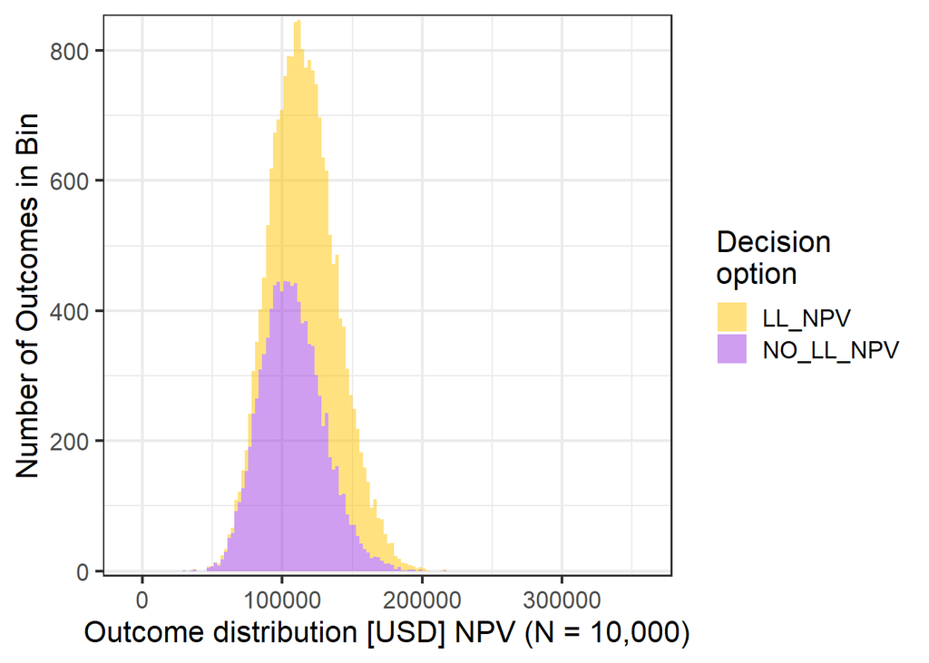

```r
hist_plt <- decisionSupport::plot_distributions(mcSimulation_object = mcSimulation_results,
                                    vars = c("LL_NPV", "NO_LL_NPV"),
                                    method = 'hist_simple_overlay',
                                    base_size = 16,
                                    colors = c("#FFC300", "#9f3ee2"),
                                    x_axis_name = "Outcome distribution [USD] NPV (N = 10,000)",
                                    y_axis_name = "Number of Outcomes in Bin")

hist_plt +
  scale_x_continuous(limits = c(-10000, 360000), breaks = seq(-100000, 300000, by = 100000))
```

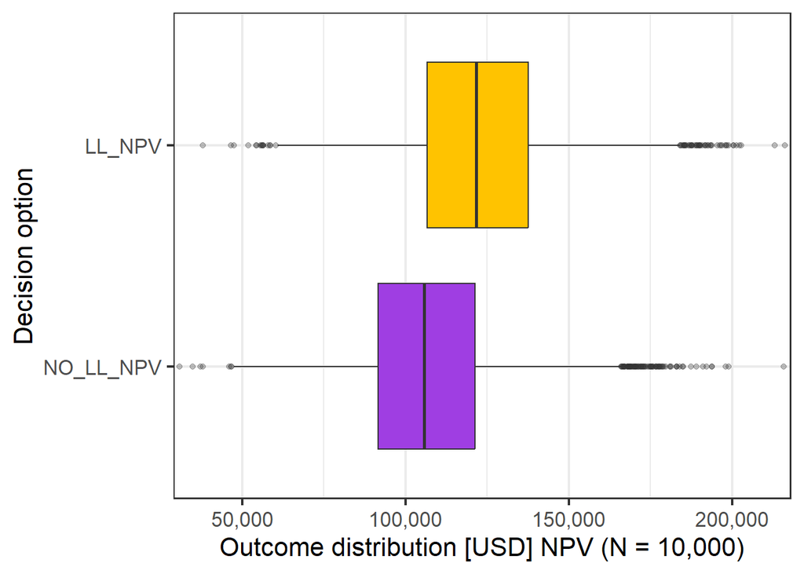

```r
NPV_names = c("Rice Production with Laser Leveling NPV", "Conventional Rice Production NPV")
decisionSupport::plot_distributions(mcSimulation_object = mcSimulation_results,
                                    vars = c("LL_NPV", "NO_LL_NPV"),
                                    method = 'boxplot',
                                    new_names = "NPV_names",
                                    base_size = 16,
                                    colors = c("#FFC300", "#9f3ee2"),
                                    x_axis_name = "Outcome distribution [USD] NPV (N = 10,000)",
                                    y_axis_name = NULL)
```

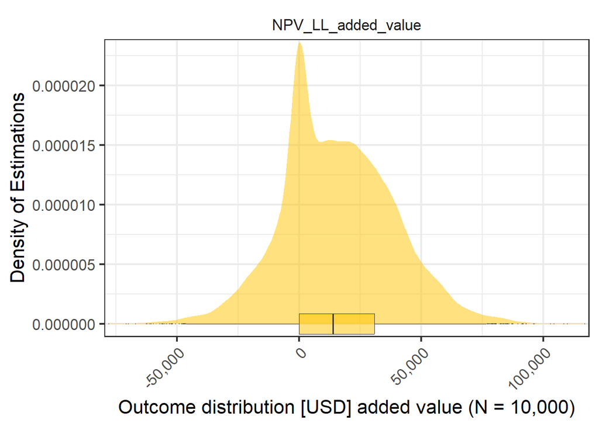

```r
decisionSupport::plot_distributions(mcSimulation_object = mcSimulation_results,
                                    vars = "NPV_LL_added_value",
                                    method = 'boxplot_density',
                                    base_size = 16,
                                    colors = "#FFC300",
                                    x_axis_name = "Outcome distribution [USD] added value (N = 10,000)",
                                    y_axis_name = "Density of Estimations")
```

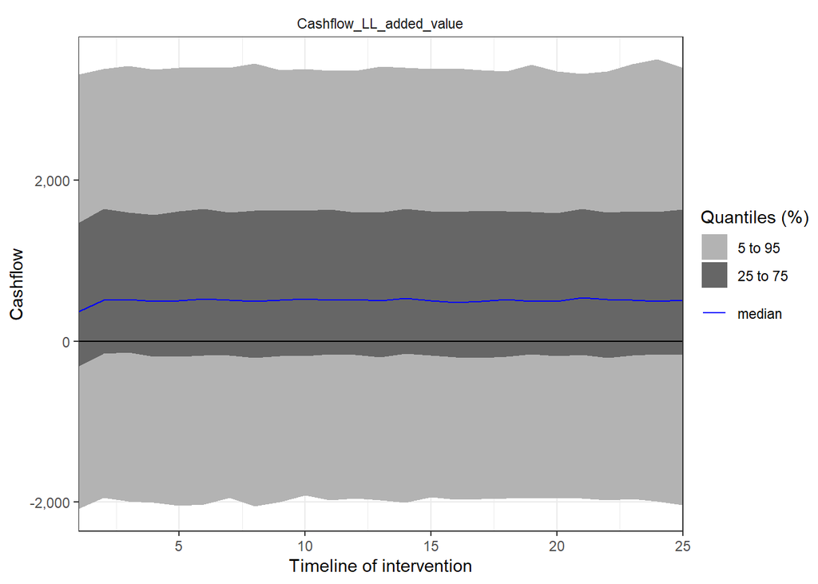

```r
plot_cashflow(mcSimulation_object = mcSimulation_results, cashflow_var_name = "Cashflow_LL_added_value")
```

## Projection to Latent Structures (PLS) analysis

Application of post-hoc analysis to `mcSimulation()` outputs.

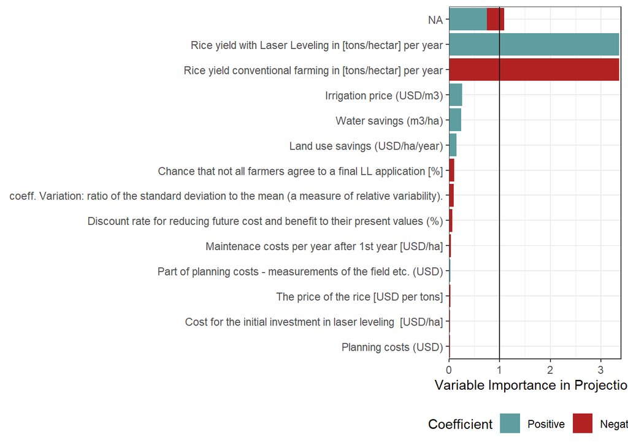

```r
#select the 3rd outcome variable "NPV_LL_added_value" from the mcSimulation results and run PLS simulation
pls_result <- plsr.mcSimulation(object = mcSimulation_results,
                  resultName = names(mcSimulation_results$y)[3], ncomp = 1)

input_table <- read.csv("Input_table_LL_decision.csv", sep = ";")

plot_pls(pls_result, input_table = input_table, threshold = 0)
```

## Value of Information Analysis

Value of Information Analysis was conducted using EVPI.

```r
#here we subset the outputs from the mcSimulation function (y) by selecting the correct variables
mcSimulation_table <- data.frame(mcSimulation_results$x, mcSimulation_results$y[1:3])

evpi <- multi_EVPI(mc = mcSimulation_table, first_out_var = "LL_NPV")
```

```
## [1] "Processing 3 output variables. This can take some time."
## [1] "Output variable 1 (LL_NPV) completed."
## [1] "Output variable 2 (NO_LL_NPV) completed."
## [1] "Output variable 3 (NPV_LL_added_value) completed."
```

[output not shown]

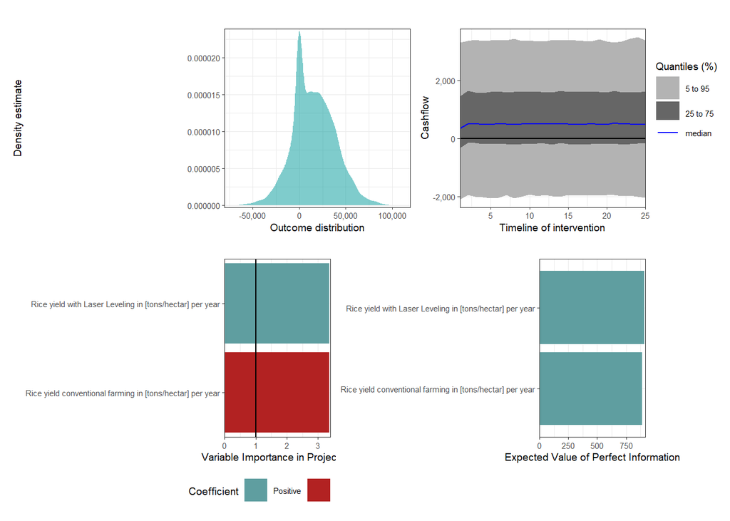

```r
plot_evpi(evpi, decision_vars = "LL_NPV")
compound_figure(mcSimulation_object = mcSimulation_results, input_table = input_table, plsrResults = pls_result, EVPIresults = evpi, decision_var_name = "NPV_LL_added_value", cashflow_var_name = "Cashflow_LL_added_value", base_size = 7)
```

# Discussion

According to Galindo-Prieto, Eriksson, and Trygg (2014), VIP values greater than 1 point are the most relevant variables, while VIP values below 0.5 are considered irrelevant. According to our results in the VIP graph, rice yield is the variable with more positive and negative impact with a higher value than 1 in the blue and red bars. After multiple runs with different values, we found that rice yield with and without LL are the variables worth investing to research more on to make more informed decisions in our context. Farm size was not a VIP in our runs, as were the VIP plot results showed by Sapkal et al. (2019), where they highlight that LL is a scale-neutral technology and is not biased towards farmers who own huge chunks of land.

By leveling rice fields, 20 - 40 % of water can be saved, and at the same time, weed can be reduced by 40% due to more consistent water coverage, which results in less pesticide use and excessive working hours (H. van Nguyen 2019).

For this vision to work, exploring the challenges and barriers is essential to the widespread adoption of laser leveling in Vietnam. This could involve assessing the availability and accessibility of laser leveling equipment, training, and technical support for farmers. As it stands, only a limited number of companies provide laser leveling services, but the numbers are constantly increasing (H. van Nguyen 2019).

In addition to policy incentives, financial support from foreign or private sources to encourage the adoption of this technology in Vietnam may benefit locals, investors, and the environment likewise. Identifying potential challenges early on was always what enables stakeholders to develop strategies to overcome them and ensure successful implementation at a larger scale. This may be what separates bad from great investors.

## Decision recommendation

Overall, the results highlighted that adopting LL is preferable in the context of smallholder cooperatives in Vietnam compared to non-adoption in terms of the costs and benefits taken into account in this study.

# Conclusion

In conclusion, the Monte Carlo simulation analysis of laser leveling intervention in rice production in Vietnam has demonstrated the potential economic benefits and positive impact of this technology. The results indicate that laser leveling has the potential to enhance economic viability and NPV in rice production.

While there can be instances where laser leveling may not provide economic net benefits, on average, it contributes positively to the added value and we showed that laser leveling has the potential to generate improved economic returns and higher NPV in rice production over a 25-year time frame for each hectare leveled.

Additionally, we conducted an analysis of cash flow over time that also indicated a positive impact of laser leveling on the overall cash flow in rice production, thereby showing how the investments start to pay off from the first year consistently, further supporting the potential economic benefits associated with laser leveling.

Through the Variable Importance in the Projection analysis, several variables have been identified as more or less important. These findings should be carefully considered and analyzed in future studies and decision-making processes.

Furthermore, apart from the economical perspective, there is also an ecological perspective that should not be completely neglected as laser leveling comes with beneficial and sustainable characteristics, namely reduced greenhouse gas emissions and erosion, less need for agrochemicals such as fertilizer and pesticides, as well as increased freshwater water savings.

However, we also addressed challenges and barriers to the widespread adoption of laser leveling, including how to ensure the accessibility of laser leveling equipment and providing training and technical support. Moreover, we noted that it is important to raise awareness for this technology as the consideration of policy incentives and financial support to promote it is necessary to implement laser leveling at a larger scale.

In conclusion, the results from this modeling highlight the potential benefits of laser leveling in rice production, creating a basis of insights for decision-makers, especially small-scale farmers and farmer cooperation, to work with. Our findings underline the importance of even more comprehensive research on the impact of laser leveling, financial and political support, as well as holistic thinking to fully explore the potential of laser leveling in economically sustainable Vietnamese rice production.

# References

Bouman, B. A. M., E. Humphreys, T. P. Tuong, and R. Barker. 2007. “Rice and Water.” In *Advances in Agronomy*, 92:187–237. Elsevier. https://doi.org/10.1016/S0065-2113(04)92004-4.

Cuaton, Ginbert P., and Laurence L. Delina. 2022. “Two Decades of Rice Research in Indonesia and the Philippines: A Systematic Review and Research Agenda for the Social Sciences.” *Humanities and Social Sciences Communications* 9 (1): 372. https://doi.org/10.1057/s41599-022-01394-z.

FOOD & AGRICULTURE ORGANIZATION. 2018. *FUTURE OF FOOD AND AGRICULTURE 2018: Alternative Pathways to 2050*. Place of publication not identified: FOOD & AGRICULTURE ORG.

Galindo-Prieto, Beatriz, Lennart Eriksson, and Johan Trygg. 2014. “Variable Influence on Projection (VIP) for Orthogonal Projections to Latent Structures (OPLS): Variable Influence on Projection for OPLS.” *Journal of Chemometrics* 28 (8): 623–32. https://doi.org/10.1002/cem.2627.

Hoang, V. P., and T. D. Vien. 2018. “Benefits and Costs of Laser Land Leveling in Paddy Field of Vietnam.” *International Journal of Engineering Research & Technology* 5 (7): 10–16.

Luedeling, Eike, Lutz Goehring, Katja Schiffers, Cory Whitney, and Eduardo Fernandez. 2022. *decisionSupport: Quantitative Support of Decision Making Under Uncertainty*. http://www.worldagroforestry.org/.

Molden, David, Theib Oweis, Pasquale Steduto, Prem Bindraban, Munir A. Hanjra, and Jacob Kijne. 2010. “Improving Agricultural Water Productivity: Between Optimism and Caution.” *Agricultural Water Management* 97 (4): 528–35. https://doi.org/10.1016/j.agwat.2009.03.023.

Ngoc, N. V., R. J. Keenan, and J. L. Herbohn. 2012. “Benefits and Costs of Laser Leveling Small-Scale Paddy Fields in Vietnam.” *Agricultural Water Management*, 115th series, 13–21.

Nguyen, Hung van. 2019. “Reporting 2021 Evidences.” https://cgspace.cgiar.org/bitstream/handle/10568/121685/OutcomesCaseStudySummary-Rice-P1581-OICS2861.pdf?sequence=1&isAllowed=y.

Nguyen, T. H., and V. H. Thang. 2019. “Application of Laser Land Leveling Technology for Rice Production in Vietnam.” *Journal of Vietnam Agricultural Science and Technology* 6 (3): 615–24.

Nguyen, T. T., V. T. Nguyen, and Y. Chen. 2021. “Evaluating the Effects of Laser Leveling on Water Saving, Rice Yield, and Economic Efficiency in Vietnam.” *Water* 2 (13): 141.

Nguyen-Van-Hung, Carlito Balingbing, Joseph Sandro, Suryakanta Khandai, Hong Chea, Thanach Songmethakrit, Pyseth Meas, et al. 2022. “Precision Land Leveling for Sustainable Rice Production: Case Studies in Cambodia, Thailand, Philippines, Vietnam, and India.” *Precision Agriculture* 23 (5): 1633–52. https://doi.org/10.1007/s11119-022-09900-8.

Oertlé, Emmanuel, Duc Toan Vu, Dinh Chuc Nguyen, Laurin Näf, and Sandra Regina Müller. 2019. “Potential for Water Reuse in Vietnam: Tiềm Năng Tái Sử Dụng Nước Tại Việt Nam.” *Journal of Vietnamese Environment* 11 (2): 65–73. https://doi.org/10.13141/jve.vol11.no2.pp65-73.

Sapkal, Sanjay, BH Kamble, Pramod Kumar, Amit Kar, and GK Jha. 2019. “Impact of Laser Land Levelling in Rice-Wheat Systems of the North-Eastern Indo-Gangetic Plains of India.” *Journal of Pharmacognosy and Phytochemistry* 1 (8): 764–69.

Seck, Papa Abdoulaye, Aliou Diagne, Samarendu Mohanty, and Marco C. S. Wopereis. 2012. “Crops That Feed the World 7: Rice.” *Food Security* 4 (1): 7–24. https://doi.org/10.1007/s12571-012-0168-1.

Tuan, L. A., P. T. T. Linh, and D. K. Nhan. 2014. “Effects of Land Leveling on Water Saving and Rice Yield in Vietnam.” *Paddy and Water Environment* 1 (12): 183–93.

Wickham, Hadley, Winston Chang, Lionel Henry, Thomas Lin Pedersen, Kohske Takahashi, Claus Wilke, Kara Woo, Hiroaki Yutani, and Dewey Dunnington. 2023. *Ggplot2: Create Elegant Data Visualisations Using the Grammar of Graphics*. https://CRAN.R-project.org/package=ggplot2.

Yang, H., A. J. Zehnder, and A. Y. Hoekstra. 2006. “Water Scarcity Analysis in the Yellow River Basin of China: Current Status and Implications.” *Water International* 2 (31): 154–62.